# Investigation into Edit Politics on Wikipedia

## A social science project by Miles Gao

### Guiding Research Question: How does increased online traffic and discourse about topics impact the editting of Wikipedia articles?

GitHub Repo link: https://github.com/mileshello/SOSC314_MGao_Project/tree/main

## Basic overview

The project uses Google Trends to determine high traffic periods for specific topics. Some basic research is then done to determine what possible causes to the spike may exist in order to understand basic context.

Using this data, a time period is selected, then the code pulls all edits within the time period to a selected group of articles and plots them by month.

Then, each edit from the time period is analyzed against the revision before and after itself to determine how many times specific words are added or removed, and some basic statistics are calculated and exported to a table. Some further analysis is then done to determine the coherance of the edits, as well as which words are most likely to survive.

**Some key limitaitons and considerations should be read before attempting a project like this or attempting an interpretation of the data and analysis. They are listed at the bottom of this before the conclusion section. They should become clear by reading this introduction, but if nothing else, read the Considerations section before observing results or running data collection yourself**

## Motivations

I started this project with the initial goal of looking at Twitter and the impact of the recent acquisition by Elon Musk on the content on the App. Unfortunately, the Twitter API is paywalled, and thus very expensive to use; still interested in online discourse, I shifted to look at Wikipedia edits; I wanted to see how increased traffic and discussion to a topic would change the edits on the page.

Wikipedia is interesting to me in part because of Elon Musk's [comments](https://https://x.com/elonmusk/status/1600200000763756544) on the site, claiming it had a "non-trivial left-wing bias." Since the acquisition, Musk engages with and promotes right-leaning talking-points X/Twitter. Because of this, I also have reason to believe he himself has something to gain by claiming such information sources are biased, pushing people towards sources with a right-wing bias.

However, even without Musk's comments, Wikipedia itself is an important source of information. Oftentimes, when using Google Search on a topic, the Wikipedia article is the top result and oftentimes automatically embedded into the search page. This makes Wikipedia edits worth a social science study in themselves. Wikipedia can be editted by anyone, but experienced editors with higher permissions are capable of "moderating" the site, resulting in the potential for moderating bias. Such a study may help users decide on whether or not Wikipedia is trustworthy, as well as helping Wikipedia itself determine if moderation should be increased or investigated for bias.

At first, I was interested in specificically discourse happening on Twitter; however, as I will discuss further deeper in the project, this would have resulted in a very limited dataset with extremely high variance. Thus, I have decided to broaden the project to look at any topics with increased traffic.

This project specifically aims to research the legal status of LGBTQ people 2022-2023 (twitter acquisition period), as well as Colombus Day 2018-2019 based on the following figure:

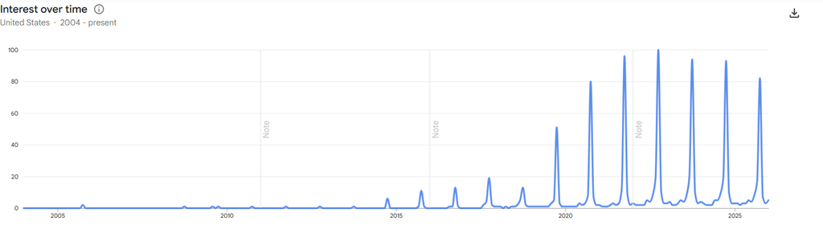

For a brief explaination on Columbus Day, Christopher Columbus and the legacy of the colonial history of the Americas has become increasingly controversial, and many have switched to use the term "Indigenous Peoples' Day."

Additionally, non-controversial articles were selected for comparison: Chocolate and Cookie.

Columbus Day Articles: ["Columbus Day", "Christopher Columbus", "Colonialism", "Indigenous Peoples' Day (United States)","Indigenous peoples of the Americas","European colonization of the Americas"]

LGBTQ Legality Articles: ["Legal status of transgender people", "Colonialism", "Content moderation", "Ethics of artificial intelligence", "Pandemic", "Identity politics"]

## Corpus - What exactly are we studying?

Wikipedia stores information on edits, including the exact revision version, as well as the date and some information about the user who committed the changes.

Given the fact that a revision contains the entire article plus some revisions, as well as the nature of Wikipedia edits, many actual "edits" are much smaller than the article themselves. Oftentimes, only singular words will be changed, including gramatical changes.

This will be important to keep in mind when applying analysis techniques, as this data is relatively unconventional. A singular edit, stripped of all segments of the article which are unchanged, may be very small and also incoherant.

## Methodology

### How can the data be used to answer the question?

The first target of analysis is **general activity**. This encompasses things like the actual words being added and removed, specific topics being edited, the survivability of different words, and edit volume over time.

The second target is **resistance to change**. This is a slightly more complex idea involving how Wikipedia responds to outside discourse and edit volume as opposed to actual events which warrant an update. For instance, does high traffic impact the survivability of certain words or topics? Does high traffic actually correlate to the article actually changing a lot?

### Article and timespan selection

This is the first step, and does not involve the code written here - it is largely background research. First, a topic should be selected which is controversial, but should not be a constantly updating situation. Information availability is always updating and changing, but still, fast-changing topics will make parsing between new information and editing difficult. (Actively changing articles are also a topic worth studying, but that is not the target of this specific research projects, which is more interested in representation of different viewpoints on objective information).

After selecting the topic, several articles (up to 10, more than 5) should be selected, with their exact titles written down. Punctiation, capitalization and spacing all matter, for the code to run correctly.

The topic should then be searched on Google Trends (perhaps several times with slightly differing search queries) to determine high traffic periods. Again, it is worth determining if the spike is a result of a major event and how much it may impact or skew results. From this, a time period of about a year should be selected to analyze the high traffic period, and an equal time period during low traffic should also be chosen for comparison.

### Raw data collection and cleaning

MediaWiki is an API service which contains a lot of data on Wikipedia articles including the edit data mentioned earlier. This will be used to find the editing volume and changes data we are looking for. Again, edits by date are pulled, "binned" by month and plotted.

Next, for the content itself, the ScikitLearn english stop words will be removed from the dataset, alongside some specific meaningless words I found which were common across articles. Additionally, mwparserfromhell will be applied to strip the formatting of the edit out of the revision, leaving us only with the content of the article as plain text.

From this, each revision will be individually parsed through, finding which words are added and removed. Each revision is its own document, and they have their own individual words which are added and removed compared with the revision before and after itself. For the majority of the analysis, the document is the whole revision, the total data is made up by increasing the times_added value for a word if it is newly present in the revision as opposed to the previous version and increasing the times_removed value for a word if it is no longer present by comparison. For topic analysis, a new document is made which through a similar technique, the document is reduced simply to the changed words with a prefix add to signify adding and rem to signify removal.

### Modeling

Finally, how will I present the data and interpret it?

Second is topic analysis, in which a lexicon will be used to determine if positive or negative terms are more likely to survive. Additionally, a topic model will be implemented. This is an unsupervised LDA model which compares the documents with only the added and removed words to determine what words are added or removed in the same revision most often. With stop words removed, this will likely be a good gauge of the coherance of edits - ie, are people actually editing with serious intent to clarify something or are they changing lots of different things across the article.

The model is trained off the editted terms given prefixes, which is fairly unconventional. What this will do is organize added and removed words by which are most likely to appear in an edit together. If a word is "added" or "removed" multiple times, its presence is "stronger," and is considered to have appeared twice. Again, in this case, removals and additions are seeparately considered.

Third is comparison: first between time periods, second between controversial articles, and third with a non-controversial article. All of this aids in our resistance to change analysis.

### Instructions on how to use the code:

**Major note:** The following code will produce all the target data and analysis we outlined in the intro for **one time period**; for comparison, you will need to run this code for multiple time periods.

1. Insert the article titles into the TITLES set from the parameters node, with each title in quotation marks and separated by a comma. eg ["Article 1", "Article 2"].
2. In the same node, select the target time period by changing the START_DATE, END_DATE variables, as well as the PARAMS values for "rvstart" and "rvend". Additionally, if you wanted to be more granular, you may change BIN_FREQ to W for weekly changes. (Optionally, you may set a line for the edit volume over time plot by changing the event_date variable. This is to signify a potential event or spike in web traffic.)
3. Ensure you upload your lexicon. I used a two separate text files "positive.txt" and "negative.txt" which are on the GitHub [repo](https://github.com/mileshello/SOSC314_MGao_Project/tree/main/Word_Changes/lexicon/subjectivity). You must upload this, or you will receive an error in the "subjectivity probability" node. If you want to use a different lexicon, you may change the files you upload, but you will need to change the load_sentiment_lexicon(x,y) parameters to your new text files. The way the code works, it requires two distinct categories (ie right-wing, left-wing). It it not necessary for the rest of the code to run, so if you don't need it, just don't run it.

### Coding begins from here:

## This first node includes basic parameters and importing:

The important parameters to change include START_DATE, END_DATE, rvstart, rvend, TITLES, and optionally event_date and BIN_FREQ.

You may also choose to add or remove STOP_WORDS. If you change NGRAMRANGE, you will add phases with several words into the dataset.

It is not advised to change MINIMUMDOCS, which removes all terms which appear in less than the specific number of articles, unless the documents you choose are extremely similar, as certain topics may be limited to one or two articles.

```python
import requests
import difflib
import csv
import re
from datetime import datetime, timezone
from collections import defaultdict
from sklearn.feature_extraction.text import CountVectorizer
from sklearn.feature_extraction.text import ENGLISH_STOP_WORDS
import matplotlib.pyplot as plt
import os
import pandas as pd

URL = "https://en.wikipedia.org/w/api.php"

HEADERS = {
    "User-Agent": "WikiEditStudy/1.0 (student project)"
}

#Volume Parameters
START_DATE = datetime(2022, 6, 1, tzinfo=timezone.utc)
END_DATE   = datetime(2023, 6, 30, tzinfo=timezone.utc)

BIN_FREQ = "M"  # M for month, W for week

event_date = pd.to_datetime("2022-10-27")

#General Parameters

PARAMS = {
    "action": "query",
    "format": "json",
    "prop": "revisions",
    "rvprop": "content",
    "rvslots": "main",
    "rvstart": "2020-06-01T23:59:59Z",
    "rvend": "2019-01-01T00:00:00Z",
    "rvlimit": "max",
    "rvdir": "older"
}

STOP_WORDS = list(ENGLISH_STOP_WORDS) + ["date", "archive","url","web","access","https","ref","org","website","www","http", "p", "s"]

NGRAMRANGE = (1,1)

MINIMUMDOCS = 1

TITLES = ["Columbus Day", "Christopher Columbus", "Colonialism", "Indigenous Peoples' Day (United States)","Indigenous peoples of the Americas","European colonization of the Americas"]

DATA_RAW_PATH = "data/raw/revision_timestamps.json"
DATA_PROCESSED_PATH = "data/processed/monthly_edit_counts.csv"
FIGURE_PATH = "figures/edit_volume_timeseries.png"

os.makedirs("data/raw", exist_ok=True)
os.makedirs("data/processed", exist_ok=True)
os.makedirs("figures", exist_ok=True)
```

# Edit Volume Data Collection

The following node creates the function for pulling the revisions over time. Afterwards, the next node is the function for binning them into months. The following two are the main execution nodes, and the last three plot the data.

```python
#Find revisions

def fetch_page_revisions(page_title, start_date, end_date, session):
    timestamps = []
    rvcontinue = None

    params = {
        "action": "query",
        "format": "json",
        "prop": "revisions",
        "titles": page_title,
        "rvlimit": 500,
        "rvprop": "timestamp",
        "rvdir": "older"
    }

    while True:
        if rvcontinue:
            params["rvcontinue"] = rvcontinue

        response = session.get(
            "https://en.wikipedia.org/w/api.php",
            params=params,
            timeout=30
        )
        data = response.json()

        pages = data.get("query", {}).get("pages", {})
        oldest_ts = None

        for page_data in pages.values():
            if "revisions" not in page_data:
                continue

            for rev in page_data["revisions"]:
                ts = datetime.fromisoformat(
                    rev["timestamp"].rstrip("Z") + "+00:00"
                ).replace(tzinfo=timezone.utc)

                timestamps.append(ts)

                if oldest_ts is None or ts < oldest_ts:
                    oldest_ts = ts

        # Stop once we go past start date
        if oldest_ts and oldest_ts < start_date:
            break

        if "continue" in data and "rvcontinue" in data["continue"]:
            rvcontinue = data["continue"]["rvcontinue"]
        else:
            break

    return [ts for ts in timestamps if start_date <= ts <= end_date]
```

```python
#Place into "bins"
def bin_timestamps(timestamps, freq="M"):
    if not timestamps:
        return pd.Series(dtype=int)

    s = pd.Series(1, index=pd.to_datetime(timestamps))
    return s.resample(freq).sum().fillna(0)
```

```python
#Get data
all_edits = defaultdict(list)

with requests.Session() as session:
    session.headers.update({
        "User-Agent": "WikipediaEditWars/1.0 (academic project)"
    })

    for page in TITLES:
         print(f"Fetching revisions for: {page}")
         edits = fetch_page_revisions(page, START_DATE, END_DATE, session)
         all_edits[page].extend(edits)
         print(f"  → {len(edits)} edits in window")


binned = []
for page, timestamps in all_edits.items():
    series = bin_timestamps(timestamps, BIN_FREQ)
    df = series.reset_index()
    df.columns = ["date", "edits"]
    df["page"] = page
    binned.append(df)

full_df = pd.concat(binned, ignore_index=True)
```

```
Fetching revisions for: Columbus Day
  → 149 edits in window
Fetching revisions for: Christopher Columbus
  → 265 edits in window
Fetching revisions for: Colonialism
  → 142 edits in window
Fetching revisions for: Indigenous Peoples' Day (United States)
  → 67 edits in window
Fetching revisions for: Indigenous peoples of the Americas
  → 284 edits in window
Fetching revisions for: European colonization of the Americas
  → 208 edits in window
```

```python
#Place into bins
binned = []
for page, timestamps in all_edits.items():
    series = bin_timestamps(timestamps, BIN_FREQ)
    df = series.reset_index()
    df.columns = ["date", "edits"]
    df["page"] = page
    binned.append(df)

full_df = pd.concat(binned, ignore_index=True)
```

```python
#Create aggregate dataframe
agg_df = (
    full_df
    .groupby("date", as_index=False)["edits"]
    .sum()
    .rename(columns={"edits": "total_edits"})
)

agg_df.to_csv(DATA_PROCESSED_PATH, index=False)
```

```python
#function for plotting individual pages
def plot_individual_pages(full_df, event_date=None):
    """
    full_df columns: date, edits, page
    """
    for page in full_df["page"].unique():
        df_page = full_df[full_df["page"] == page]

        plt.figure()
        plt.bar(df_page["date"], df_page["edits"], width = 25)
        if event_date is not None:
            plt.axvline(event_date, linestyle="--")

        plt.title(f"Monthly Wikipedia Edits: {page}")
        plt.xlabel("Time")
        plt.ylabel("Number of Edits")
        plt.tight_layout()

        filename = page.replace(" ", "_").replace("/", "_")
        plt.savefig(f"figures/{filename}_timeseries.png")
        plt.show()
```

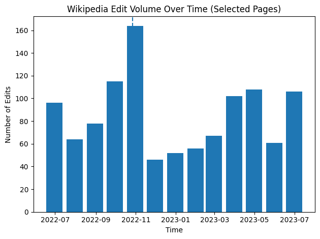

```
Pipeline complete.
Raw data saved to: data/raw/revision_timestamps.json
Processed data saved to: data/processed/monthly_edit_counts.csv
Figure saved to: figures/edit_volume_timeseries.png
```

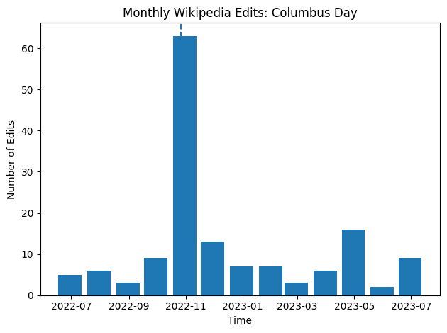

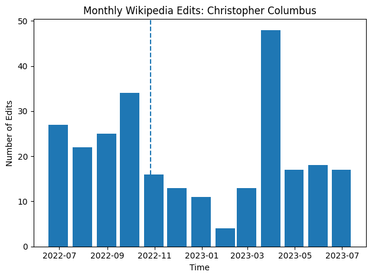

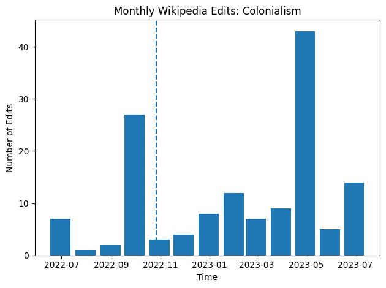

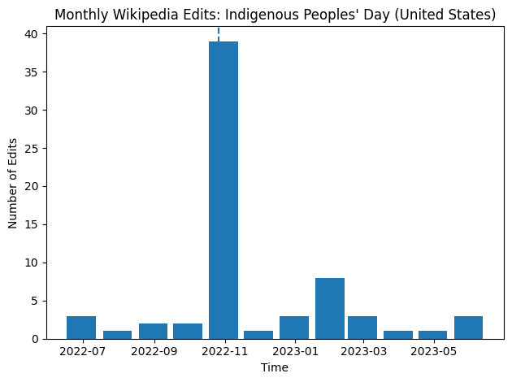

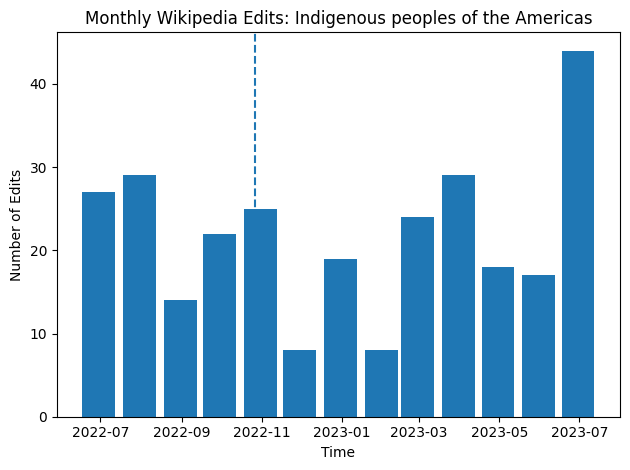

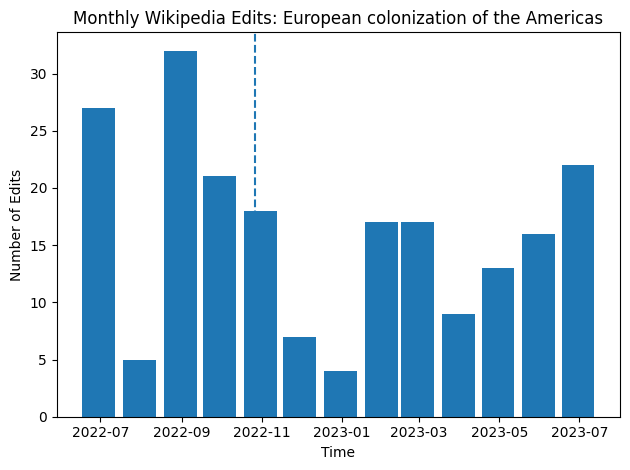

```python
#aggregate plotting + ind plotting
plt.figure()
plt.bar(agg_df["date"], agg_df["total_edits"], width = 25)
plt.axvline((event_date), linestyle="--") ##adds a line at point of interest
plt.title("Wikipedia Edit Volume Over Time (Selected Pages)")
plt.xlabel("Time")
plt.ylabel("Number of Edits")
plt.tight_layout()
plt.savefig(FIGURE_PATH)
plt.show()

print("\nPipeline complete.")
print(f"Raw data saved to: {DATA_RAW_PATH}")
print(f"Processed data saved to: {DATA_PROCESSED_PATH}")
print(f"Figure saved to: {FIGURE_PATH}")


plot_individual_pages(full_df, event_date=event_date)
```

# Word Revisions as Data

This task is more complicated, and will be longer.

### Tool building

1. Vectorizer, including specialized common terms, potential n grams
2. Stripper, using "mwparserfromhell" specifically designed to strip formatting from wikipedia edits; also manual removal of spacing formatting like /n and /s
3. Edit/revision finding function

```python
# tokenizer - vectorizer
#no max df, as its not very relevant to our project
vectorizer = CountVectorizer(min_df=MINIMUMDOCS, stop_words=STOP_WORDS, ngram_range = NGRAMRANGE)
```

```python
# imports code from the following link to "strip" edits of their formatting, leaving only the text. For instance, all URLs are removed. https://github.com/earwig/mwparserfromhell
!pip install mwparserfromhell
import mwparserfromhell
##https://github.com/earwig/mwparserfromhell
def clean_wikitext(wikitext):
    code = mwparserfromhell.parse(wikitext)
    text = code.strip_code()
    text = text.replace("\n", " ").replace("\t", " ")
    text = re.sub(r"\s+", " ", text)
    return text.strip()
```

```python
#edits finder
def get_revisions(title):
    revisions = []
    cont = {}

    while True:
        params = PARAMS.copy()
        params.update(cont)
        params["titles"] = title

        r = requests.get(URL, params=params, headers=HEADERS)
        data = r.json()

        pages = data["query"]["pages"]
        page = next(iter(pages.values()))

        for rev in page["revisions"]:
            slot = rev["slots"]["main"]
            text = slot.get("*", slot.get("content", ""))
            if text:
              # stripping
              clean_text = clean_wikitext(text)
              revisions.append(clean_text)

        if "continue" in data:
            cont = data["continue"]
        else:
            break

    #edits after stripping - not quite raw
    raw_filename = f"wiki_raw_articles_{title.replace(' ', '_')}.csv"
    raw_rows = []
    with open(raw_filename, "w", newline="", encoding="utf-8") as f:
        writer = csv.writer(f)
        writer.writerow(["revision_index", "text"])

        for i, text in enumerate(revisions):
            writer.writerow([i, text])

    print(f"Saved raw stripped articles: {raw_filename}")


    return revisions
```

### Main data collection node

Runs the earlier tool functions, finding the stripped articles and then finding the number of additions and removals of each word for each individual article, as well as the aggregates for each article.

Note: This function deals with hundreds to thousands of revisions, each of which is a whole article; thus, it will take a very long time to finish running.

```python
    # prep aggregate
    aggregate_added = defaultdict(int)
    aggregate_removed = defaultdict(int)

    # prep LDA, make each edit into individual "document"
    ind_edits_blind = []
    ind_edits_dist= []

    for title in TITLES:
        revisions = get_revisions(title)

        added_counts = defaultdict(int)
        removed_counts = defaultdict(int)

        X = vectorizer.fit_transform(revisions)
        feature_names = vectorizer.get_feature_names_out()

        edited_words_blind = []
        edited_words_dist = []

        for i in range(X.shape[0] - 1):
            old_words = X[i].toarray()[0]
            new_words = X[i + 1].toarray()[0]

            for idx, word in enumerate(feature_names):
                diff = new_words[idx] - old_words[idx]

                if diff > 0:
                    added_counts[word] += diff
                    edited_words_blind.extend([word]*diff)
                    edited_words_dist.extend([f"ADD_{word}"]*diff)
                elif diff < 0:
                    removed_counts[word] += -diff
                    edited_words_blind.extend([word]*(-diff))
                    edited_words_dist.extend([f"REM_{word}"]*(-diff))

            if edited_words_blind:
                ind_edits_blind.append(" ".join(edited_words_blind))
                ind_edits_dist.append(" ".join(edited_words_dist))

        # individual results
        page_words = set(added_counts) | set(removed_counts)
        page_results = []

        for word in page_words:
            added = added_counts.get(word, 0)
            removed = removed_counts.get(word, 0)
            net = added - removed
            abs = added + removed

            page_results.append({
                "word": word,
                "times_added": added,
                "times_removed": removed,
                "net_change": net,
                "absolute_change": abs
            })

            # update aggregate counters
            aggregate_added[word] += added
            aggregate_removed[word] += removed

        # sort per page
        page_results.sort(key=lambda x: x["times_added"], reverse=True)

        # write per-page CSV
        filename = f"wiki_word_summary_{title.replace(' ', '_')}.csv"
        with open(filename, "w", newline="", encoding="utf-8") as f:
            writer = csv.DictWriter(
                f,
                fieldnames=["word", "times_added", "times_removed", "net_change", "absolute_change"]
            )
            writer.writeheader()
            writer.writerows(page_results)

        print(f"Saved {filename}")

    # create aggregate csv
    aggregate_words = set(aggregate_added) | set(aggregate_removed)
    aggregate_results = []

    for word in aggregate_words:
        added = aggregate_added.get(word, 0)
        removed = aggregate_removed.get(word, 0)
        net = added - removed
        abs = added + removed

        aggregate_results.append({
            "word": word,
            "times_added": added,
            "times_removed": removed,
            "net_change": net,
            "absolute_change": abs
        })

    aggregate_results.sort(key=lambda x: x["times_added"], reverse=True)

    with open("wiki_word_summary_aggregate.csv", "w", newline="", encoding="utf-8") as f:
        writer = csv.DictWriter(
            f,
            fieldnames=["word", "times_added", "times_removed", "net_change", "absolute_change"]
        )
        writer.writeheader()
        writer.writerows(aggregate_results)

    print("Saved wiki_word_summary_aggregate.csv")
```

```
Saved raw stripped articles: wiki_raw_articles_Columbus_Day.csv
Saved wiki_word_summary_Columbus_Day.csv
Saved raw stripped articles: wiki_raw_articles_Christopher_Columbus.csv
Saved wiki_word_summary_Christopher_Columbus.csv
Saved raw stripped articles: wiki_raw_articles_Colonialism.csv
Saved wiki_word_summary_Colonialism.csv
Saved raw stripped articles: wiki_raw_articles_Indigenous_Peoples'_Day_(United_States).csv
Saved wiki_word_summary_Indigenous_Peoples'_Day_(United_States).csv
Saved raw stripped articles: wiki_raw_articles_Indigenous_peoples_of_the_Americas.csv
Saved wiki_word_summary_Indigenous_peoples_of_the_Americas.csv
Saved raw stripped articles: wiki_raw_articles_European_colonization_of_the_Americas.csv
Saved wiki_word_summary_European_colonization_of_the_Americas.csv
Saved wiki_word_summary_aggregate.csv
```

## End of data collection, cleaning, aggregation, beginning of analysis

# Topic model

The LDA topic model setup as described in the methods. You may change the TOPICNUMBER from 7, but be aware that coherance may be sensitive.

```python
!pip install pyLDAvis
from sklearn.feature_extraction.text import CountVectorizer
from sklearn.decomposition import LatentDirichletAllocation

#parameters:

TOPICNUMBER = 7
RANDOMSTATE = 123
```

### Running Topic Model

One is "blind," meaning it does not differentiate between additions and removals, while the second does differentiate.

```python
lda_blind = LatentDirichletAllocation(n_components=TOPICNUMBER, random_state=RANDOMSTATE)
lda_blind.fit(vectorizer.fit_transform(ind_edits_blind))

vectorizer.get_feature_names_out()

feature_names = vectorizer.get_feature_names_out()
for topic_idx, topic in enumerate(lda_blind.components_):
    top_features_ind = topic.argsort()[:-10 - 1:-1]
    top_features = [feature_names[i] for i in top_features_ind]
    print(f"Topic #{topic_idx + 1}: {', '.join(top_features)}")


lda_dist = LatentDirichletAllocation(n_components=TOPICNUMBER, random_state=RANDOMSTATE)
lda_dist.fit(vectorizer.fit_transform(ind_edits_dist))

vectorizer.get_feature_names_out()

feature_names = vectorizer.get_feature_names_out()
for topic_idx, topic in enumerate(lda_dist.components_):
    top_features_ind = topic.argsort()[:-30 - 1:-1]
    top_features = [feature_names[i] for i in top_features_ind]
    print(f"Topic #{topic_idx + 1}: {', '.join(top_features)}")
```

```
Topic #1: ottoman, colonialism, colonisation, colonization, colonial, colonies, colonisers, colonizers, empire, south
Topic #2: columbus, day, jerusalem, peoples, american, indigenous, italian, voyages, society, people
Topic #3: peepeepoopoopeepeepoo, peepeepoopoogreat, fixed, dont, pleasepeepeepoo, indigenous, native, 000, americas, america
Topic #4: north, foot, stepped, actually, america, columbus, llkjjl, reasons, varying, dates
Topic #5: colonialism, colonial, colonies, european, empire, philippines, people, south, country, islands
Topic #6: day, columbus, holiday, states, indigenous, new, día, la, americas, world
Topic #7: americas, european, new, american, colonization, america, north, spanish, thumb, south
Topic #1: rem_indigenous, rem_native, add_indigenous, add_native, add_children, rem_children, rem_american, rem_americas, rem_america, rem_hla, add_88, add_america, add_indígena, add_pertenece, add_pueblo, add_nación, rem_pertenece, rem_nación, rem_indígena, rem_pueblo, add_la, rem_la, rem_natives, …
Topic #2: rem_day, add_day, rem_columbus, rem_americas, add_columbus, add_americas, rem_new, add_new, rem_european, rem_american, add_european, add_american, add_america, rem_america, rem_spanish, add_spanish, rem_north, rem_indigenous, rem_colonization, add_north, add_colonization, rem_italian, add…
Topic #3: add_peepeepoopoopeepeepoo, rem_peepeepoopoopeepeepoo, add_fixed, add_peepeepoopoogreat, add_dont, rem_peepeepoopoogreat, rem_dont, rem_fixed, add_pleasepeepeepoo, rem_pleasepeepeepoo, rem_indigenous, add_native, add_indigenous, rem_native, rem_000, add_000, rem_americas, add_america, add_m…
Topic #4: add_atthe, rem_dc, rem_carolina, add_actually, add_stepped, rem_atthe, add_story, add_10, rem_stepped, rem_actually, rem_pdf, add_dakotahttps, add_davidmontgomery, add_17194651, add_argusleader, rem_dakotain, rem_20indigenous, rem_6adc0c8b1611416eb20f4a743aa082e5, rem_6c, rem_20day, rem_20…
Topic #5: rem_columbus, add_columbus, rem_jerusalem, rem_society, rem_voyages, rem_carol, rem_delaney, rem_history, rem_comparative, rem_2006, rem_studies, rem_ultimate, rem_april, rem_goal, add_km, add_jerusalem, rem_gold, rem_italian, add_americas, rem_spanish, add_italian, rem_pp, rem_writes, add…
Topic #6: add_ottoman, rem_ottoman, rem_colonialism, add_colonialism, rem_colonisation, add_colonization, add_colonial, rem_colonies, rem_colonial, add_colonisation, add_colonies, rem_colonization, rem_colonisers, add_colonizers, rem_empire, rem_south, rem_africa, add_colonized, rem_thumb, add_empir…
Topic #7: rem_colonialism, add_colonialism, add_colonial, rem_european, rem_colonies, add_colonies, rem_colonial, rem_empire, rem_south, add_philippines, add_empire, rem_philippines, rem_people, rem_country, add_people, rem_africa, rem_thumb, rem_colony, add_european, add_country, rem_british, rem_p…
```

## Subjectivity Model

The following line of code determines the files used as the lexicon: polarity_lexicon = load_sentiment_lexicon("positive.txt", "negative.txt") If you want to change the lexicon, this is what you will want to change.

```
Probability of high net/absolute change by sentiment:

           net_high  abs_high
sentiment
-1         0.197740  0.367232
 0         0.186501  0.413558
 1         0.168478  0.423913
```

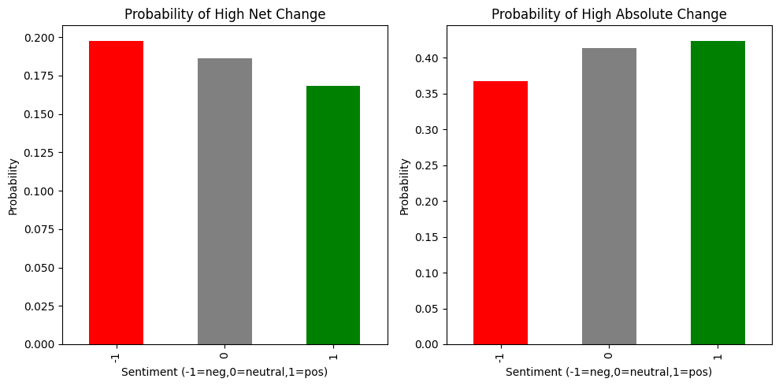

```python
df = pd.read_csv("wiki_word_summary_aggregate.csv")

# import lexicon
def load_sentiment_lexicon(pos_file, neg_file):
    lexicon = {}
    # Positive words → +1
    with open(pos_file, encoding="utf-8") as f:
        for line in f:
            lexicon[line.strip()] = 1
    # Negative words → -1
    with open(neg_file, encoding="utf-8") as f:
        for line in f:
            lexicon[line.strip()] = -1
    return lexicon
polarity_lexicon = load_sentiment_lexicon("positive.txt", "negative.txt")

def get_word_sentiment(word, lexicon):
    if not isinstance(word, str):
        return 0  # treat as neutral
    return lexicon.get(word.lower(), 0)

df["sentiment"] = df["word"].apply(lambda w: get_word_sentiment(w, polarity_lexicon))

# net_change and absolute_change
median_net = df["net_change"].median()
median_abs = (df["times_added"] + df["times_removed"]).median()

df["net_high"] = df["net_change"] > median_net
df["abs_high"] = (df["times_added"] + df["times_removed"]) > median_abs

# finding probability per sentiment, sorting by -1, 0, 1
summary = df.groupby("sentiment")[["net_high", "abs_high"]].mean()
summary = summary.sort_index()  # optional: sort by -1,0,1
print("Probability of high net/absolute change by sentiment:\n")
print(summary)

# plotting
fig, ax = plt.subplots(1, 2, figsize=(10,5))

summary["net_high"].plot(kind="bar", ax=ax[0], color=["red","gray","green"])
ax[0].set_title("Probability of High Net Change")
ax[0].set_xlabel("Sentiment (-1=neg,0=neutral,1=pos)")
ax[0].set_ylabel("Probability")

summary["abs_high"].plot(kind="bar", ax=ax[1], color=["red","gray","green"])
ax[1].set_title("Probability of High Absolute Change")
ax[1].set_xlabel("Sentiment (-1=neg,0=neutral,1=pos)")
ax[1].set_ylabel("Probability")

plt.tight_layout()
plt.show()
```

## Survival probabilty

Finally, the last basic statistic. This node creates the survival fraction by comparing a words' additions to its net change to determine how likely a word is to survive.

```python
# Load the aggregate word csv
df = pd.read_csv("wiki_word_summary_aggregate.csv")

# Compute survival fraction
# Avoid division by zero if times_added is 0
df["survival_fraction"] = df.apply(
    lambda row: row["net_change"] / row["times_added"] if row["times_added"] > 0 else 0,
    axis=1
)

# Sort by survival fraction descending (highest survival first)
df_sorted = df.sort_values(by="survival_fraction", ascending=False)

# Optionally, inspect top surviving words
print(df_sorted[["word", "times_added", "times_removed", "net_change", "survival_fraction"]].head(20))

# Save results
df_sorted.to_csv("wiki_word_survival.csv", index=False)
print("Saved word-level survival to wiki_word_survival.csv")
```

```
                word  times_added  times_removed  net_change  \
3120  christoffarime            1              0           1
3117           dayof            1              0           1
3116         urgency            1              0           1
3115          length            1              0           1
3114      florentine            1              0           1
3110             edu            1              0           1
3109            rené            1              0           1
3064              23            1              0           1
3088              38            1              0           1
3087             dal            1              0           1
3086      brazilians            1              0           1
3085            1750            1              0           1
3077    anthropology            1              0           1
3068           apart            1              0           1
```

[output cut: 29 more lines]

# Results

## Basic Statistics (Columbus Day 2019):

Sorted by absolute change:

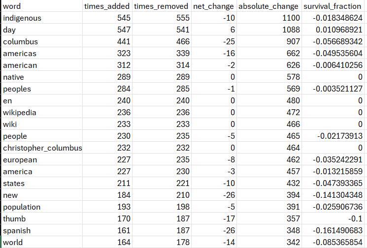

Sorted by net change:

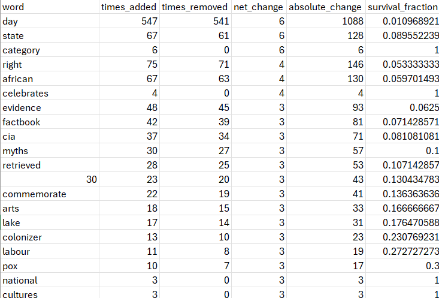

Net change is consistently low across the board, an observation which suggests that Wikipedia resists change fairly well. Additionally, while absolute change does have many charged phrases topping the absolute change statistic, most of the high net_change words are fairly objective, with certain exceptions like "myths" or "colonizer."

## Topics (Columbus Day 2019)

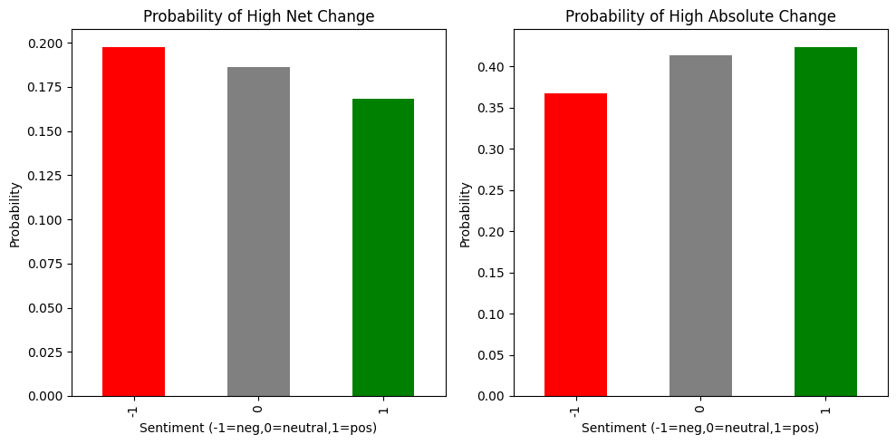

Both cases demonstrate a trend, negative with increasing positivity of language for net change and positive with increasing positivity for absolute change. It should be noted that the values are very similar. Regardless, the trend itself seems to indicate some level of bias. Negative words are more likely to have high net change despite being less likely to have high absolute change. The converse is true for positive terms.

### Topic model (Columbus Day 2019, non blind):

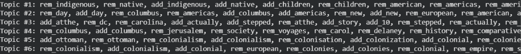

## Time Comparison: Columbus Day 2018

### Edit Volume over Time - Columbus Day articles:

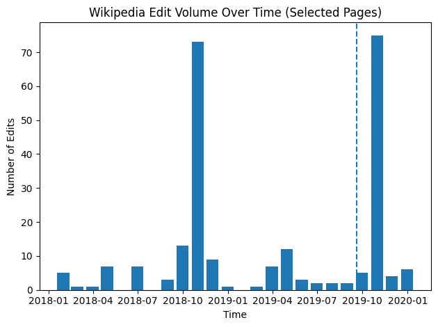

Despite the much larger spike on Google Trends on Columbus Day 2019, 2018 actually peaked very similarly on Wikipedia edits. This alone suggests that Wikipedia brigading is not common among mainstream users. However, given, that Wikipedia "edit war" participants are more likely to be active in political spaces, this doesn't mean Wikipedia edit brigading doesnt occur. For further analysis, the word data will be important.

## Equivalent Figures and Word Data 2018

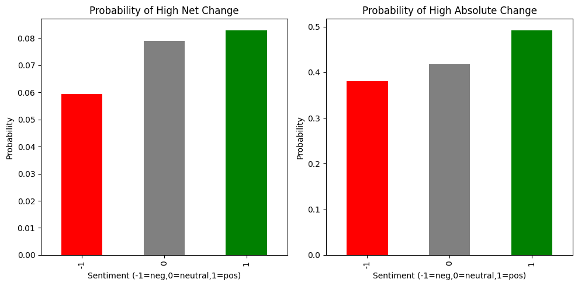

Sorted by Net Change:

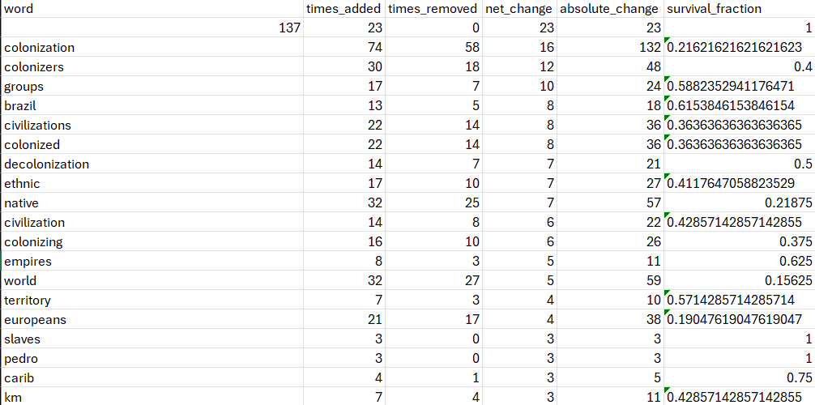

When compared to the target time period, the earlier time period appears to in fact have more words with significantly higher net change. Additionally, the probability of high net change is reversed across the subjectivity, but the high absolute change remained the same. For this topic, it seems as though positive terms are favored by absolute change, meaning they are the most often added even if they are eventually removed. Net change, on the other hand, seems to favor negative terms during timmes of significant traffic.

Generally, the fact that higher net change occured during a time of significantly lower internet traffic suggests a resistence to change from outside discourse.

## Topic Comparison: LGBTQ+ Legality, 2023

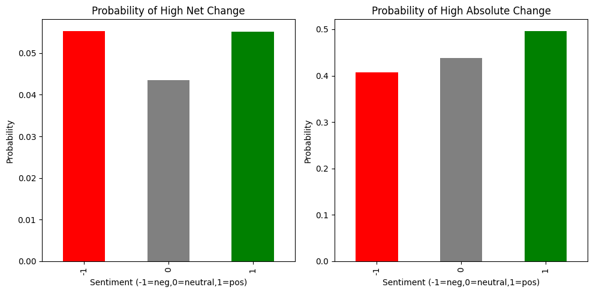

Sorted by Net Change:

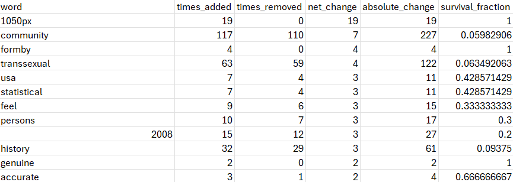

In this case, both negative and positive terms had a high probability of high net change, while high absolute change continued to be most highly probable in positive terms. The net change numbers were quite similar to the Columbus Day results despite lower absolute change numbers, again suggesting a strong resistance to change. The high net change again slightly leans towards survivability of negative terms, given that they are less likely to have high absolute change but more likely to have high net change.

## Comparison to Control - Cookie and Chocolate Articles Sorted

Words sorted by Net Change:

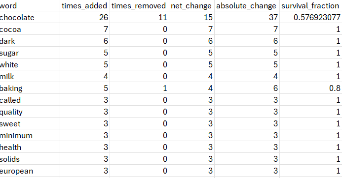

As one may expect, the absolute change and times_added numbers are low across the board, suggesting low edit volume; the articles are non-controversial, and there are less of them. However, the net_change is comparable or even exceeds the net_change values from target articles. This again demonstrates high resistance to change.

# Considerations and Limitations

- This project is NOT a strong evaluation of bias on Wikipedia as a whole; it simply is not being analyzed directly. This project examines **revisions** as opposed to entire articles. (A better method for this would be to run sentiment analysis on articles categorized by political affiliation; studies that do this exist)
- High Variance: For our dataset, many documents will be extremely small, as many edits are miniscule. The net_change and absolute_change differences are intended to combat this, as absolute_change favors all edits, while basic gramatical or structural changes will be cleaned out by net_change, as the removal cancels the re-add in most cases. Still, however, training a model on such small documents, oftentimes with incoherant passages, is likely to have mistakes. Similarly, the positivity-negativity analysis also shows similar low probability of high change across the board. This suggests that small changes may impact the appearance of the results greatly.
- Trolling: There is a high possibility of completely meaningless data from users who commit revisions for the sole purpose of a joke, without real political bias on either side; it is difficult to isolate this type of behavior from radically biased edits, which are part of our dataset.
- Limitation of Dataset: because of the unusual dataset, it is difficult to find meaningful conclusions. Again, the incoherant nature of edits mean that certain methods, such as a direct sentiment analysis, are difficult; additionally, words lack context (eg: quotes, negation). This is the reason many of the results are basic. The best way to work with a dataset like this is to get what is useful from the simple data and try to draw conclusions.

### Diagnostics

Preprocessing descisions include the selection and number of articles, as well as tokenization.

The selection and number of articles can both certainly impact the results, which is why I selected one in which positive is associated with left-wing politics (LGBTQ+ legislation), one in which positive is associated with right-wing (Columbus), and control articles. In this case, indeed the number of articles gave us a large amount of data in which many words had several hundred to over 1000 absolute change. The control articles also accurately reflected the expectation for low_controversy articles, as their edit volume across a similar time period was much smaller. Thus, the article selection process was considered successful.

Tokenization was a little more difficult, but without the removal of stopwords, gramatical changes would dominate the charts. Additionally, the addition of mwparserfromhell removed many meaningless formatting terms like https from the article, some of which were actual English words. Combing through the data reveals that very-few-if-any totally irrelevant words topped the charts, suggesting a good stopping point for stopword removal.

# Conclusions:

## General Activity and Topics

Ultimately, surviving edits seem to be low in bias. When sorting by high net change, most words are objective. Sorting by high absolute change demonstrates more poltically charged terms, but often times they are removed for often than added for a negative net-change.

Bias does appear in our results however. For the Indigenous Peoples' Day and LGBTQ+ legality target time periods, we found that negative words were more likely to remain. This would likely correlate with a negative bias towards the LGBTQ+ community, as well as towards Christopher Columbus (viewpoints generally associated with opposite sides of the American political spectrum). However, the difference is so small and the amount of high change is so low that this bias is not enough to counteract the intuitive results given by survivability.

Finally, the topic model suggests that most edits are written in good faith, being on topic, further detracting from the bias of edits. The coherance of the topics demonstrate that most edits have a singular, sensical topic, and that it is rare for editors to edit several different parts of an article to chang ethe general sentiment - this is more logically sound in the pursuit of objective, informative articles. Even if coherant, the edits themselves may still be biased, however.

# References:

Jain, Tejashri Inadarchand, and Dipak Nemade. “Recognizing contextual polarity in phrase-level sentiment analysis.” International Journal of Computer Applications, vol. 7, no. 5, 10 Sept. 2010, pp. 12–21, https://doi.org/10.5120/1160-1453.

“Main Page.” Wikipedia, Wikimedia Foundation, 6 Feb. 2026, www.wikipedia.org/. projects, Contributors to Wikimedia. “Main Page of a Wikimedia Project.”

MediaWiki, Wikimedia Foundation, Inc., 29 Dec. 2023, www.mediawiki.org/wiki/MediaWiki.

Zeng, Yan. “Sentiment Lexicon.” GitHub, 7 Sept. 2019, github.com/zengyan-97/Sentiment-Lexicon?utm_source=chatgpt.com.